# Analysis of Big Healthcare Databases - Exercises

#### Introduction

The goal of these exercises is to explore the structure of an electronic health records (EHR)-derived data set and some of the common challenges encountered in working with healthcare-derived data. We will also practice implementing some statistical methods introduced throughout the short course to address these issues. To do this we will use a synthetic data set simulated to mimic the structure of a real EHR-derived data set. <

#### Encounter data

This data set includes one row per outpatient encounter.

```r
encounter = read.csv("https://raw.githubusercontent.com/rhubb/ASA_EHR_ShortCourse/master/data/encounter.csv", head=T)
```

> patientid: Patient ID

> servicedate: Date of the encounter

> age: Age in years

> race: Provider-reported patient race

> proc: CPT codes for procedure performed; codes 99211-99215 are for evaluation and management of established patients in an outpatient setting

> diag: ICD-9 (on or before 10/31/2015) or ICD-10 (after 10/31/2015) for primary diagnosis; a few diagnosis codes of interest are T2DM ICD-9 = “250.00”; T2DM ICD-10 = “E11.9”; T1DM ICD-9 = “250.01”; T1DM ICD-10 = “E10.9”; Depression ICD-9 = “296.2”,“296.9”,“296.3”,“300.4”; Depression ICD-10 = “F32.9”,“F41.8”,“F33.9”

> prov: CMS provider specialty code; a few provider codes of potential interest are General Practice = “1”, General Dermatology = “7”, Family practice = “8”, Internal Medicine = “11”, Neurology = “13”, Ophthalmology = “18”, Psychiatry = “26”, Pediatric Medicine = “37”, Endocrinology = “46”

#### Prescription medication data

This data set includes one row per prescription recorded on the date of an outpatient encounter included in the encounters file.

```r
meds = read.csv("https://raw.githubusercontent.com/rhubb/ASA_EHR_ShortCourse/master/data/meds.csv", head=T)
```

> patientid: Patient ID

> presdate: Date of the prescription

> drug: Drug class

#### Measures data

This data set includes one row per anthropometric or laboratory measurement recorded on the date of an outpatient encounter included in the encounters file.

```r
measures = read.csv("https://raw.githubusercontent.com/rhubb/ASA_EHR_ShortCourse/master/data/measures.csv", head=T)
```

> patientid: Patient ID

> measurement: Numeric value of the measurement

> measuretype: Description of the laboratory or anthropometric test (height in cm, weight in kg, glucose in mg/dl, hemoglobin A1c (hba1c) in %)

#### Validation data

This data set includes one row per patient for 998 patients randomly selected for manual chart review to determine gold-standard type 2 diabetes status.

```r
validation = read.csv("https://raw.githubusercontent.com/rhubb/ASA_EHR_ShortCourse/master/data/validation.csv", head=T)
```

> patientid: Patient ID

> T2DM: Type 2 diabetes status based on manual chart review (1 = T2DM, 0 = no evidence of T2DM)

#### Install R packages

- For these exercises you will need the *rpart*, *pROC* *boot*, and *gee* packages.
- If you have not already, please install these packages now.

```r
install.packages("RColorBrewer")
install.packages("rpart")
install.packages("pROC")
install.packages("boot")
install.packages("gee")
library(RColorBrewer)
library(rpart)
library(pROC)
library(boot)
library(gee)
```

### Exercises

1. **Data Quality Evaluation.** The first task in analysis of EHR data is data exploration and visualization to identify and resolve data errors. Using the measures data set, we will carry out a descriptive analysis. Are there any observations that seem likely to be errors? What are some techniques we can use to identify errors? What are some options for handling possibly erroneous data points once they have been identified?

```r
## Use summary statistics and plots to investigate basic characteristics of the data

summary(measures)
```

```
##    patientid          servicedate     measurement        measuretype
##  Min.   :100172   2015-10-04:   40   Min.   : -0.1016   chol   : 2543
##  1st Qu.:320683   2010-01-23:   39   1st Qu.: 88.3321   glucose: 6387
##  Median :546440   2005-09-30:   37   Median :131.5963   hba1c  : 4500
##  Mean   :545570   2015-04-19:   37   Mean   :127.9784   height :30484
##  3rd Qu.:773212   2009-06-04:   35   3rd Qu.:163.7256   weight :30484
##  Max.   :999973   2009-08-03:   35   Max.   :935.9580
##                   (Other)   :74175
```

```r
# separate variables by measurement type
height <- measures[measures$measuretype == "height",-4]
names(height) <- c("patientid","servicedate","height")

weight <- measures[measures$measuretype == "weight",-4]
names(weight) <- c("patientid","servicedate","weight")

glucose <- measures[measures$measuretype == "glucose",-4]
names(glucose) <- c("patientid","servicedate","glucose")

hba1c <- measures[measures$measuretype == "hba1c",-4]
names(hba1c) <- c("patientid","servicedate","hba1c")

chol <- measures[measures$measuretype == "chol",-4]
names(chol) <- c("patientid","servicedate","chol")

# explore number of observations available per patient for each measurement type

summary(c(table(factor(height$patientid, levels = unique(encounter$patientid)))))
```

```
##    Min. 1st Qu.  Median    Mean 3rd Qu.    Max.
##    0.00    2.00    3.00    3.07    4.00   38.00
```

```r
summary(c(table(factor(weight$patientid, levels = unique(encounter$patientid)))))
```

```
##    Min. 1st Qu.  Median    Mean 3rd Qu.    Max.
##    0.00    2.00    3.00    3.07    4.00   38.00
```

```r
summary(c(table(factor(glucose$patientid, levels = unique(encounter$patientid)))))
```

```
##    Min. 1st Qu.  Median    Mean 3rd Qu.    Max.
##  0.0000  0.0000  0.0000  0.6432  1.0000 10.0000
```

```r
summary(c(table(factor(hba1c$patientid, levels = unique(encounter$patientid)))))
```

```
##    Min. 1st Qu.  Median    Mean 3rd Qu.    Max.
##  0.0000  0.0000  0.0000  0.4532  1.0000  6.0000
```

```r
summary(c(table(factor(chol$patientid, levels = unique(encounter$patientid)))))
```

```
##    Min. 1st Qu.  Median    Mean 3rd Qu.    Max.
##  0.0000  0.0000  0.0000  0.2561  0.0000  4.0000
```

```r
# number of children with no measures available

sum(c(table(factor(height$patientid, levels = unique(encounter$patientid)))) == 0)
```

```
## [1] 33
```

```r
sum(c(table(factor(weight$patientid, levels = unique(encounter$patientid)))) == 0)
```

```
## [1] 33
```

```r
sum(c(table(factor(glucose$patientid, levels = unique(encounter$patientid)))) == 0)
```

```
## [1] 5141
```

```r
sum(c(table(factor(hba1c$patientid, levels = unique(encounter$patientid)))) == 0)
```

```
## [1] 6235
```

```r
sum(c(table(factor(chol$patientid, levels = unique(encounter$patientid)))) == 0)
```

```
## [1] 7644
```

```r
# summarize distribution of variables across all patients, looking for values outside the plausible range

summary(height$height)
```

```
##    Min. 1st Qu.  Median    Mean 3rd Qu.    Max.
##    99.4   151.8   162.9   162.9   173.6   504.9
```

```r
summary(weight$weight)
```

```
##     Min.  1st Qu.   Median     Mean  3rd Qu.     Max.
##  -0.1016  77.8705  96.1002  99.9169 116.0298 935.9580
```

```r
summary(glucose$glucose)
```

```
##    Min. 1st Qu.  Median    Mean 3rd Qu.    Max.
##   28.06   79.04  100.75  115.97  128.67  481.01
```

```r
summary(hba1c$hba1c)
```

```
##    Min. 1st Qu.  Median    Mean 3rd Qu.    Max.
##   2.180   5.227   6.163   6.351   7.326  13.617
```

```r
summary(chol$chol)
```

```
##    Min. 1st Qu.  Median    Mean 3rd Qu.    Max.
##   41.31  187.36  328.48  290.60  373.36  519.34
```

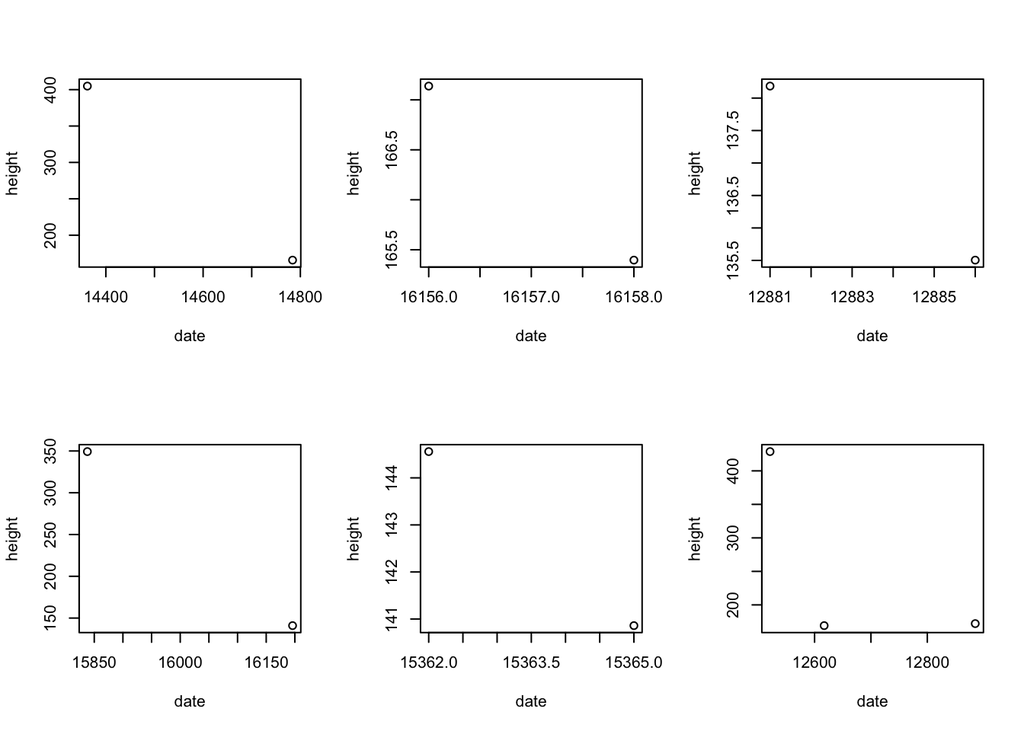

```r
# values that are clearly outside the plausible range can be eliminated, those that seem unlikely should be
# noted for discussion with clinical collaborators

weight$weight <- ifelse(weight$weight < 0, NA, weight$weight)
extreme.heights <- weight$patientid[height$height > 300] # flag patients with height > 3 m
extreme.weights <- weight$patientid[weight$weight > 200] # flag patients with weight > 200 kg

# implausible patterns in longitudinal measurements provide an additional means of identifying data errors

height.s <- split(data.frame(height$servicedate,height$height),height$patientid)
weight.s <- split(data.frame(as.Date(weight$servicedate),weight$weight),weight$patientid)
glucose.s <- split(data.frame(as.Date(glucose$servicedate),glucose$glucose),glucose$patientid)
hba1c.s <- split(data.frame(as.Date(hba1c$servicedate),hba1c$hba1c),hba1c$patientid)

# summarize rate of change and within-patient variability

longrate <- function(x){
  days <- as.numeric(as.Date(x[,1]))
  measure <- x[,2]
  mod <- lm(measure ~ days)
  rate <- mod$coef[2]
  residsd <- summary(mod)$sigma
  return(c(rate,residsd))
}

height.lm <- t(sapply(height.s,longrate))

# take a look at a few patients with implausible trajectories

height.decrease.ind <- which(height.lm[,1] < -0.5)
par(mfrow = c(2,3))
for (i in 1:6){
  plot(as.numeric(as.Date(height.s[[height.decrease.ind[i]]][,1])),height.s[[height.decrease.ind[i]]][,2], xlab = "date", ylab = "height")
}
```

```r
# a few of these measures look very suspicious, as if one measurement is about 2.5 times the other
# take a closer look at an example case

height[height$patientid == names(height.decrease.ind[1]),]
```

```
##      patientid servicedate   height
## 3418    136655  2009-04-28 404.8859
## 3420    136655  2010-06-24 165.7610
```

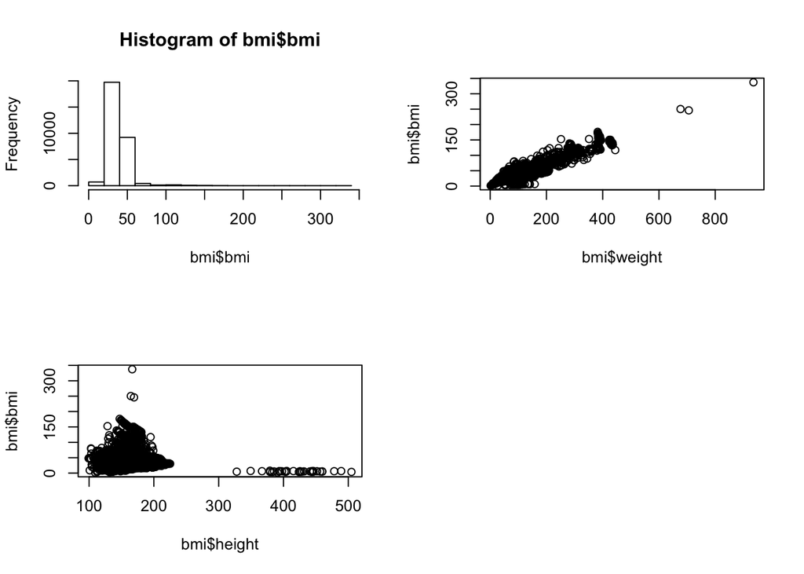

```r
# generate BMI and look for implausible values

height$iddate <- paste(height$patientid,height$servicedate)
weight$iddate <- paste(weight$patientid,weight$servicedate)
bmi <- merge(height,weight,by = "iddate") # merge height and weight data
bmi$bmi <- bmi$weight/(bmi$height/100)^2

par(mfrow = c(2,2))
hist(bmi$bmi)
plot(bmi$weight,bmi$bmi)
plot(bmi$height,bmi$bmi)

# unusual groupings in BMI plots suggest patients with wrong units for height or weight
# select a rule for eliminating these heights or weights

bmi$height <- ifelse(bmi$height > 250, bmi$height/2.54, bmi$height)
bmi$bmi <- bmi$weight/(bmi$height/100)^2

par(mfrow = c(1,2))
```

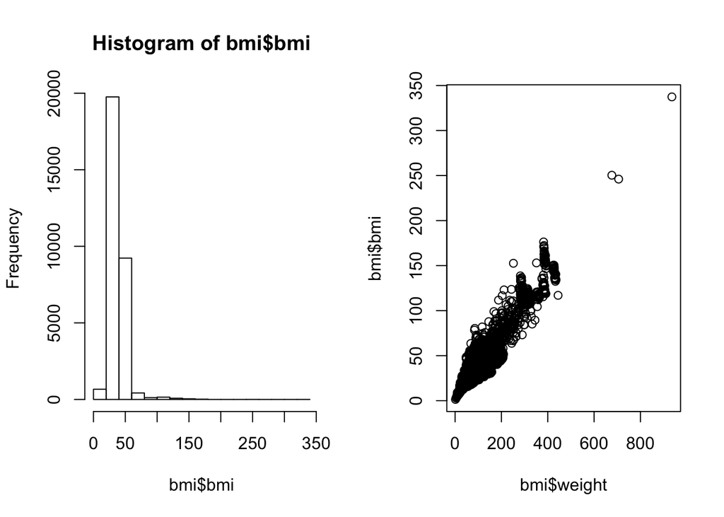

```r
hist(bmi$bmi)
plot(bmi$weight,bmi$bmi)
```

2. **Phenotype Extraction.** We will next explore a few alternative approaches to deriving a type 2 diabetes (T2DM) phenotype from this data set. To do so, we first need to reduce the data to one observation per patient considering what data elements might be of use at the patient-level. Next we will use the validation data to develop a prediction model for T2DM using logistic regression and CART. Finally, we will apply the eMERGE T2DM rule to these data. How do the sensitivity, specificity, PPV, and NPV of these approaches compare?

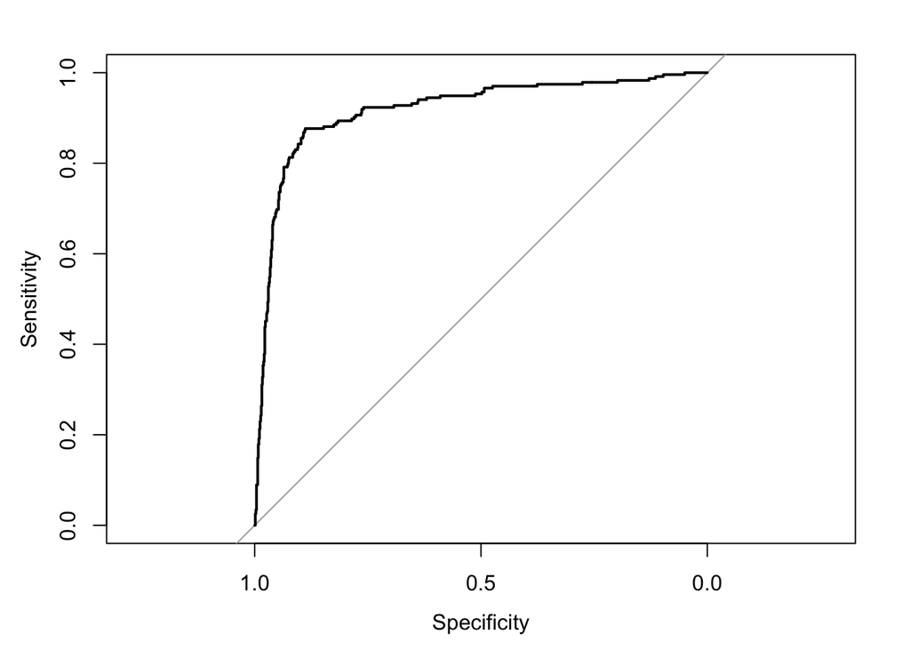

```r
## Aggregate data to the patient level

# aggregate numeric measurements using the earliest, mean and maximum observed values

bmi$bmimean <- unsplit(sapply(split(bmi$bmi,bmi$patientid.x),mean,na.rm = T),bmi$patientid.x)
bmi$bmimax <- unsplit(sapply(split(bmi$bmi,bmi$patientid.x),max,na.rm = T),bmi$patientid.x)
bmi$firstbmi <- unsplit(sapply(split(bmi$bmi,bmi$patientid.x),function(x){x[1]}),bmi$patientid.x)

glucose$glucosemean <- unsplit(sapply(split(glucose$glucose,glucose$patientid),mean,na.rm = T),glucose$patientid)
glucose$glucosemax <- unsplit(sapply(split(glucose$glucose,glucose$patientid),max,na.rm = T),glucose$patientid)

hba1c$hba1cmean <- unsplit(sapply(split(hba1c$hba1c,hba1c$patientid),mean,na.rm = T),hba1c$patientid)
hba1c$hba1cmax <- unsplit(sapply(split(hba1c$hba1c,hba1c$patientid),max,na.rm = T),hba1c$patientid)

chol$cholmean <- unsplit(sapply(split(chol$chol,chol$patientid),mean,na.rm = T),chol$patientid)
chol$cholmax <- unsplit(sapply(split(chol$chol,chol$patientid),max,na.rm = T),chol$patientid)

encounter$agemean <- unsplit(sapply(split(encounter$age,encounter$patientid),mean,na.rm = T),encounter$patientid)
encounter$firstage <- unsplit(sapply(split(encounter$age,encounter$patientid),min,na.rm = T),encounter$patientid)

# look for any occurence of diabetes diagnosis codes, insulin, metformin,
# or visit to an endocrinologist within the period of interest
# T2DM ICD-9 = "250.00", T2DM ICD-10 = "E11.9", T1DM ICD-9 = "250.01", T1DM ICD-10 = "E10.9"
# Endocrinologist Medicare specialty code = 46

anycode <- function(x,code){
  code.present <- x %in% code
  return(sum(code.present)>0)
}

# Count number of occurences of code

sumcode <- function(x,code){
  code.present <- x %in% code
  return(sum(code.present))
}

# Determine whether metformin prescription precedes insulin prescription
# Returns 1 if only metformin prescribed or metformin prescribed before insulin
# otherwise returns 0

codeorder <- function(x){
  metdates <- as.Date(x$dates[x$drugs == "metformin"])
  insdates <- as.Date(x$dates[x$drugs == "insulin"])
  if (length(metdates) == 0) metfirst <- 0
  else if (length(metdates) > 0 & length(insdates) == 0) metfirst <- 1
  else if (length(metdates) == 0 & length(insdates) == 0) metfirst <- 0
  else metfirst <- suppressMessages(1*(min(metdates) < min(insdates)))
  return(metfirst)
}

# any T2DM code
encounter$T2DM <- unsplit(sapply(split(encounter$diag,encounter$patientid),anycode,code = c("250.00","E11.9")),encounter$patientid)

# number of T2DM codes
encounter$T2DMnum <- unsplit(sapply(split(encounter$diag,encounter$patientid),sumcode,code = c("250.00","E11.9")),encounter$patientid) # number of occurence of T2DM code

# any T1DM code
encounter$T1DM <- unsplit(sapply(split(encounter$diag,encounter$patientid),anycode,code = c("250.01","E10.9")),encounter$patientid)

# any visit to an endocrinologist
encounter$endo <- unsplit(sapply(split(encounter$prov,encounter$patientid),anycode,code = "46"),encounter$patientid)

# any depression diagnosis
encounter$dep <- unsplit(sapply(split(encounter$diag,encounter$patientid),anycode,code = c("296.2","296.9","296.3","300.4","F32.9","F41.8","F33.9")),encounter$patientid)

# any insulin prescription
meds$anyinsulin <- unsplit(sapply(split(meds$drug,meds$patientid),anycode,code = "insulin"),meds$patientid)

# any metformin prescription
meds$anymetformin <- unsplit(sapply(split(meds$drug,meds$patientid),anycode,code = "metformin"),meds$patientid)

# metformin prescription precedes insulin prescription
meds$metforminfirst <- unsplit(sapply(split(data.frame(dates=meds$presdate,drugs=meds$drug),
                       meds$patientid),codeorder),meds$patientid)


## Create merged dataset with one observation per patient and aggregate variables

encounter1 <- encounter[!duplicated(encounter$patientid),c("patientid","agemean","firstage","race","gender","T2DM","T1DM","endo","T2DMnum","dep")]
bmi1 <- bmi[!duplicated(bmi$patientid.x),c("patientid.x","bmimean","bmimax","firstbmi")]
names(bmi1) <- c("patientid","bmimean","bmimax","firstbmi")
glucose1 <- glucose[!duplicated(glucose$patientid),c("patientid","glucosemean","glucosemax")]
hba1c1 <- hba1c[!duplicated(hba1c$patientid),c("patientid","hba1cmean","hba1cmax")]
chol1 <- chol[!duplicated(chol$patientid),c("patientid","cholmean","cholmax")]
meds1  <- meds[!duplicated(meds$patientid),c("patientid","anyinsulin","anymetformin","metforminfirst")]

data1 <- Reduce(function(x,y){merge(x,y, all = T)},list(encounter1,bmi1,glucose1,hba1c1,chol1,meds1,validation))

# create indicators for availability of any glucose or HbA1c measures

data1$anyglucose <- !is.na(data1$glucosemean)
data1$anyhba1c   <- !is.na(data1$hba1cmean)

# set insulin and metformin to false for patients with no medication data

data1$anyinsulin <- ifelse(is.na(data1$anyinsulin),FALSE,data1$anyinsulin)
data1$anymetformin <- ifelse(is.na(data1$anymetformin),FALSE,data1$anymetformin)

## Phenotyping models using gold standard labels from validation data set to construct prediction models for T2DM

## Logistic regression

mod.glm <- glm(T2DMv ~ T2DM + T1DM + bmimean + anyglucose + anyhba1c + anyinsulin + anymetformin, data = data1, family = "binomial")

# logistic regression-based phenotype
data1$T2DMglm <- predict(mod.glm, newdata = data1)

# evaluate performance of logistic regression phenotype
pred.glm <- na.omit(data.frame(pred = data1$T2DMglm,true = data1$T2DMv))
perf.glm <- roc(pred.glm$true, pred.glm$pred, auc = TRUE, print.auc = TRUE, show.thres = TRUE)

plot(perf.glm)
```

```r
# Logistic regression AUC
perf.glm$auc
```

```
## Area under the curve: 0.9182
```

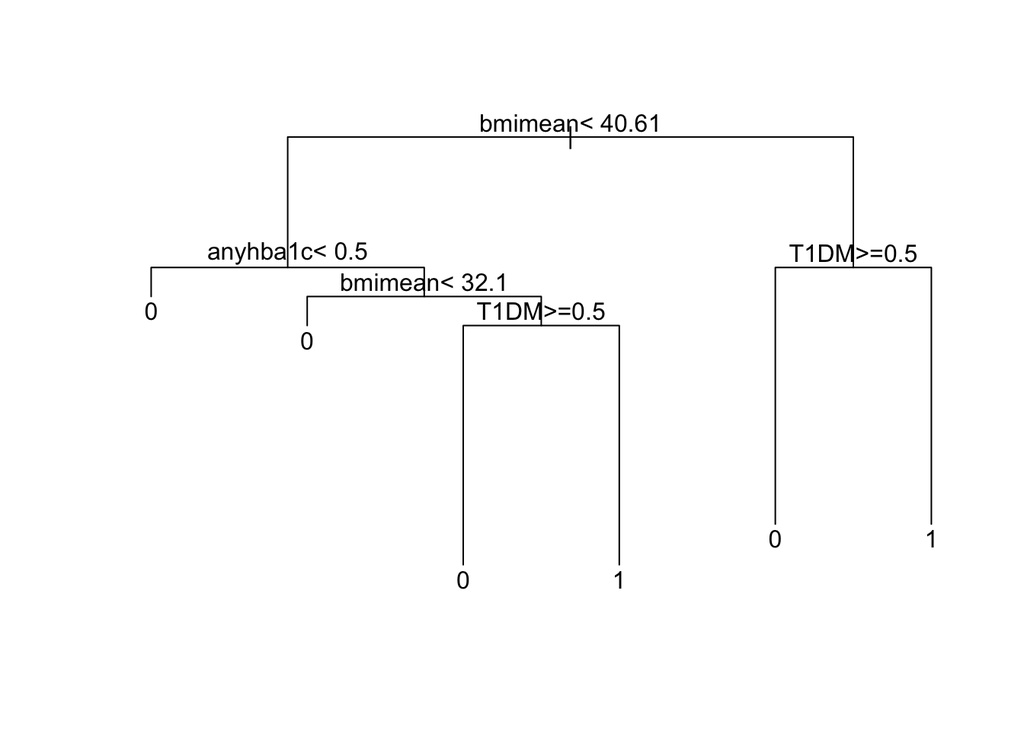

```r
## CART

set.seed(20190805)
mod.cart <- rpart(T2DMv ~ T2DM + T1DM  + bmimean + anyglucose + anyhba1c, data = data1, method = "class")
mod.pruned<- prune(mod.cart, cp= mod.cart$cptable[which.min(mod.cart$cptable[,"xerror"]),"CP"])

par(xpd = NA) # prevent text labels from being cut off
plot(mod.pruned)
text(mod.pruned)
```

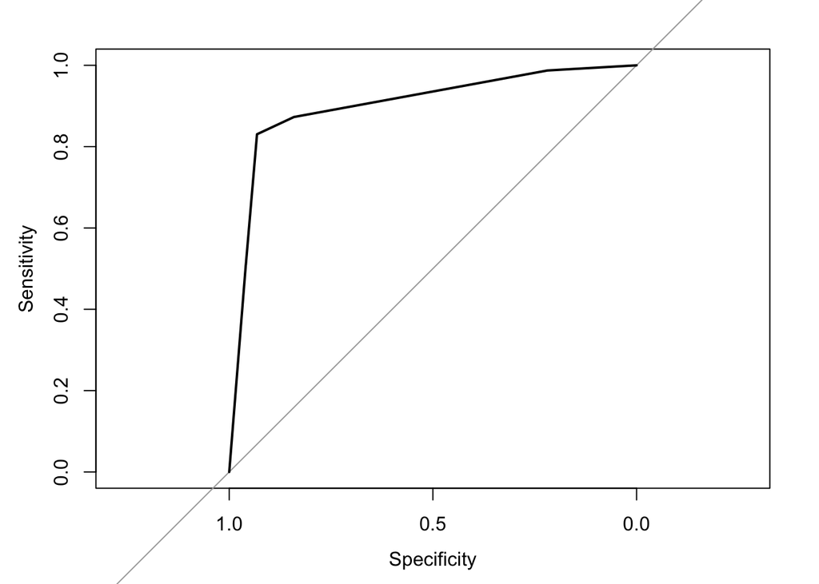

```r
# predicted probabilities of T2DM based on CART
data1$T2DMcart <- predict(mod.pruned, newdata = data1, type = "prob")

# binary T2DM phenotype based on CART
data1$T2DMcart.class <- as.numeric(as.character(predict(mod.pruned, newdata = data1, type = "class")))

# evaluate performance of continuous CART phenotype
pred.cart <- na.omit(data.frame(pred = data1$T2DMcart[,2],true = data1$T2DMv))
perf.cart <- roc(pred.cart$true, pred.cart$pred, auc = TRUE, print.auc = TRUE, show.thres = TRUE)

plot(perf.cart)
```

```r
# CART AUC
perf.cart$auc
```

```
## Area under the curve: 0.9022
```

```r
## eMERGE T2DM rule

T2DM.rule <- function(x){
  if (x$T1DM ==1) T2DM <- 0
  else{
    if (x$T2DM ==1){
      if (x$anyinsulin == 1){
        if (x$anymetformin == 0){
          if (x$T2DMnum < 2){
            T2DM <- 0
          } else{
            T2DM <- 1
          }
        } else{
          if (x$metforminfirst == 0){
            T2DM <- 0
          } else{
            T2DM <- 1
          }
        }
      } else{
        if (x$anymetformin == 1){
          T2DM <- 1
        } else{
          if ((!is.na(x$glucosemax) & x$glucosemax > 200) | (!is.na(x$hba1cmax) & x$hba1cmax > 6.5)){
            T2DM <- 1
          } else{
            T2DM <- 0
          }
        }
      }
    } else{
      if (x$anymetformin == 0){
        T2DM <- 0
      } else{
        if ((!is.na(x$glucosemax) & x$glucosemax > 200) | (!is.na(x$hba1cmax) & x$hba1cmax > 6.5)){
          T2DM <- 1
        } else{
          T2DM <- 0
        }
      }
    }
  }
  return(T2DM)
}

data1$T2DMemerge <- unsplit(sapply(split(data1,data1$patientid),T2DM.rule),data1$patientid)

# eMERGE specificity
1-mean(data1$T2DMemerge[data1$T2DMv == 0 & !is.na(data1$T2DMv)])
```

```
## [1] 0.9685039
```

```r
# eMERGE sensitivity
mean(data1$T2DMemerge[data1$T2DMv == 1 & !is.na(data1$T2DMv)])
```

```
## [1] 0.1059322
```

```r
# eMERGE PPV
mean(data1$T2DMv[data1$T2DMemerge == 1],na.rm = T)
```

```
## [1] 0.5102041
```

```r
# eMERGE NPV
1 - mean(data1$T2DMv[data1$T2DMemerge == 0],na.rm = T)
```

```
## [1] 0.7776607
```

3. **Missing Data.** Next we will explore missing data in an EHR-derived data set. Suppose we want to use our T2DM phenotype from exercise 2 to explore the relationship between total cholesterol and T2DM diagnosis. How might we define total cholesterol? Using this definition, how much missingness is there? Is missingness related to any other factors in the data set? Use IPW with a single module or multiple modules to account for missingness in your analysis of the association between total cholesterol and T2DM.

```r
## For most real examples we would want to define our exposure (cholesterol) in a window around
## cohort entry. For this toy example we will just use all available data.

# Percent missing cholesterol
mean(is.na(data1$cholmean))

# Number of encounters per patient
encounter$numvisit <- rep(c(table(encounter$patientid)), times = c(table(encounter$patientid)))
summary(encounter$numvisit)

# Merge number of encounters onto data set with one observation per patient
numvisit <- encounter[!duplicated(encounter$patientid),c("patientid","numvisit")]
data1 <- merge(data1,numvisit)

# Look for factors associated with missing cholesterol
data1$misschol <- is.na(data1$cholmean)
misschol.mod <- glm(misschol ~ firstage + race + gender + firstbmi, data = data1, family = binomial)

# Generate probability of missingness from this model
data1$pmisschol1[!is.na(data1$firstbmi)] <- 1-predict(misschol.mod, type = "response", data = data1)

# Estimate probability of missingness using a two stage model
# first estimate probability of missingness conditional on making an endocrinologist visit
misschol.mod.2 <- glm(misschol ~ endo, data = data1, family = binomial)
data1$pmisschol2 <- 1-predict(misschol.mod.2, type = "response")

# next estimate probability of missingness among those with and without endocrinologist visit
misschol.mod.20 <- glm(misschol ~ firstage + race + gender + firstbmi, data = data1[data1$endo == 0,], family = binomial)
misschol.mod.21 <- glm(misschol ~ firstage + race + gender + firstbmi, data = data1[data1$endo == 1,], family = binomial)
data1$pmisschol20[!is.na(data1$firstbmi)] <- 1-predict(misschol.mod.20, type = "response", newdata = data1[!is.na(data1$firstbmi),])
data1$pmisschol21[!is.na(data1$firstbmi)] <- 1-predict(misschol.mod.21, type = "response", newdata = data1[!is.na(data1$firstbmi),])

# create combined probability of having an observed cholesterol value given these two modules
data1$pmisschol.mod <- data1$pmisschol2*data1$pmisschol21+(1-data1$pmisschol2)*data1$pmisschol20

## Compare one module and two module probabilities of being observed
plot(data1$pmisschol1, data1$pmisschol.mod)

## Fit regression models using IPW to account for missingness in cholesterol

# Model using 1 step weights
data1$w1 <- 1/data1$pmisschol1
chol.mod1 <- glm(T2DMcart.class~ firstage + factor(race) + gender + cholmean, data = data1, weights = w1)
summary(chol.mod1)

# Model using 2 step weights
data1$w.mod <- 1/data1$pmisschol.mod
chol.mod2 <- glm(T2DMcart.class~ firstage + factor(race) + gender + cholmean, data = data1, weights = w.mod)
summary(chol.mod2)
```

4. **Confounding by Utilization Intensity.** Accounting for the intensity of healthcare utilization in analyses. How much variability is there in the intensity of utilization in this data set? Use a measure of intensity of utilization to account for informed presence bias in an analysis of the association between depression diagnosis and T2DM.

```r
## Summarize intensity of utilization using number of outpatient visits
hist(data1$numvisit)

## Analyze association between BMI and T2DM with and without conditioning on visit intensity
dep.glm1 <- glm(T2DMcart.class ~ firstage + factor(race) + gender + dep, data = data1, family = "binomial")
summary(dep.glm1)

dep.glm2 <- glm(T2DMcart.class ~ firstage + factor(race) + gender + numvisit + dep, data = data1, family = "binomial")
summary(dep.glm2)

# compare odds ratios before and after adjustment
cbind(c(exp(dep.glm1$coef),NA),exp(dep.glm2$coef))
```

5. **Outcome Misclassification.** Use the classic Magder and Hughes approach to accounting for outcome misclassification to account for phenotyping error in an analysis of the association between having a depression diagnosis code and T2DM using the CART-derived T2DM phenotype.

```r
## Analysis without additional adjustment variables

# first compute sensitivity and specificity using validation data
sens <- mean(as.numeric(as.character(data1$T2DMcart.class[data1$T2DMv == 1 & !is.na(data1$T2DMv)])))
sens
```

```
## [1] 0.8305085
```

```r
spec <- 1-mean(as.numeric(as.character(data1$T2DMcart.class[data1$T2DMv == 0 & !is.na(data1$T2DMv)])))
spec
```

```
## [1] 0.9317585
```

```r
# compute odds ratios
a <- sum(data1$T2DMcart.class == 1 & data1$dep == 1)
b <- sum(data1$T2DMcart.class == 0 & data1$dep == 1)
c <- sum(data1$T2DMcart.class == 1 & data1$dep == 0)
d <- sum(data1$T2DMcart.class == 0 & data1$dep == 0)

or.std <- a*d/(b*c) # standard odds ratio
or.mh <- (a/(a+b)-(1-spec))/(c/(c+d)-(1-spec))*(sens-c/(c+d))/(sens-a/(a+b)) # Magder and Hughes adjusted odds ratio

or.std
```

```
## [1] 1.660301
```

```r
or.mh
```

```
## [1] 2.039454
```

```r
## Adjusted analysis via logistic regression using EM algorithm

# posterior probability of Y
post.prob <- function(phat,S,sens,spec){
  post.probY <- ifelse(S== 1, sens*phat/(sens*phat+(1-spec)*(1-phat)),
                       (1-spec)*phat/((1-spec)*phat+sens*(1-phat)))
  return(post.probY)
}

# EM algorithm proposed by Magder and Hughes
mh.EM <- function(fmla, sens, spec, tol = 10^-4, maxit = 10){
  data1$Y <- data1$T2DMcart.class
  or1 <- glm(fmla, data = data1, family = "binomial")
  p0 <- predict(or1, type = "response")
  dif <- 1
  j <- 0
  while (dif > tol & j < maxit){
    w <- post.prob(p0,data1$T2DMcart.class,sens,spec)
    data2 <- rbind(data1, data1)
    data2$w <- c(w,1-w)
    data2$Y <- c(rep(1,nrow(data1)),rep(0,nrow(data1)))
    suppressWarnings(or2 <- glm(fmla, data = data2, family = "binomial", weights = w))
    p0 <- predict(or2, type = "response", newdata = data1)
    dif <- max(abs(or1$coef-or2$coef))
    or1 <- or2
    j <- j+1
  }
  if (dif > tol) return("Did not converge")
  else return(or2)
}

# fit model
fmla.endo <- formula("Y ~ firstage + factor(race) + gender + dep")
mod.MH <- mh.EM(fmla.endo, sens, spec, maxit = 100)
summary(mod.MH)
```

```
##
## Call:
## glm(formula = fmla, family = "binomial", data = data2, weights = w)
##
## Deviance Residuals:
##      Min        1Q    Median        3Q       Max
## -0.86276  -0.54903  -0.04668   0.25393   1.62845
##
## Coefficients:
##                      Estimate Std. Error z value Pr(>|z|)
## (Intercept)          -1.10977    0.22899  -4.846 1.26e-06 ***
## firstage             -0.03695    0.01207  -3.061  0.00221 **
## factor(race)Black    -0.09127    0.15363  -0.594  0.55245
## factor(race)Hispanic -0.12132    0.18038  -0.673  0.50122
## factor(race)Other    -0.47279    0.21942  -2.155  0.03119 *
## factor(race)Unknown   0.01962    0.20675   0.095  0.92438
## factor(race)White    -0.10438    0.15237  -0.685  0.49332
## genderMale           -0.36095    0.05324  -6.780 1.20e-11 ***
## depTRUE               0.70922    0.05413  13.103  < 2e-16 ***
## ---
## Signif. codes:  0 '***' 0.001 '**' 0.01 '*' 0.05 '.' 0.1 ' ' 1
##
## (Dispersion parameter for binomial family taken to be 1)
##
##     Null deviance: 9365.6  on 19859  degrees of freedom
## Residual deviance: 9119.0  on 19851  degrees of freedom
## AIC: 10691
##
## Number of Fisher Scoring iterations: 4
```

```r
exp(mod.MH$coef)
```

```
##          (Intercept)             firstage    factor(race)Black factor(race)Hispanic    factor(race)Other  factor(race)Unknown    factor(race)White           genderMale              depTRUE
##            0.3296358            0.9637270            0.9127709            0.8857505            0.6232640            1.0198177            0.9008854            0.6970150            2.0324087
```

```r
# naive model for comparison
mod.cart <- glm(T2DMcart.class ~ firstage + factor(race) + gender + dep, data = data1, family = "binomial")
summary(mod.cart)
```

```
##
## Call:
## glm(formula = T2DMcart.class ~ firstage + factor(race) + gender +
##     dep, family = "binomial", data = data1)
##
## Deviance Residuals:
##     Min       1Q   Median       3Q      Max
## -0.9227  -0.7600  -0.6624  -0.5777   2.0471
##
## Coefficients:
##                      Estimate Std. Error z value Pr(>|z|)
## (Intercept)          -0.87459    0.20894  -4.186 2.84e-05 ***
## firstage             -0.02820    0.01096  -2.573   0.0101 *
## factor(race)Black    -0.07271    0.14103  -0.516   0.6061
## factor(race)Hispanic -0.09222    0.16511  -0.559   0.5765
## factor(race)Other    -0.31337    0.19466  -1.610   0.1074
## factor(race)Unknown   0.02465    0.18994   0.130   0.8967
## factor(race)White    -0.08578    0.13988  -0.613   0.5397
## genderMale           -0.25616    0.04828  -5.306 1.12e-07 ***
## depTRUE               0.49862    0.04858  10.264  < 2e-16 ***
## ---
## Signif. codes:  0 '***' 0.001 '**' 0.01 '*' 0.05 '.' 0.1 ' ' 1
##
## (Dispersion parameter for binomial family taken to be 1)
##
##     Null deviance: 10676  on 9929  degrees of freedom
## Residual deviance: 10526  on 9921  degrees of freedom
## AIC: 10544
##
## Number of Fisher Scoring iterations: 4
```

```r
exp(mod.cart$coef)
```

```
##          (Intercept)             firstage    factor(race)Black factor(race)Hispanic    factor(race)Other  factor(race)Unknown    factor(race)White           genderMale              depTRUE
##            0.4170339            0.9721921            0.9298685            0.9119057            0.7309761            1.0249559            0.9177954            0.7740166            1.6464420
```

```r
# model based on validation data only
mod.valid <- glm(T2DMv ~ agemean + factor(race) + gender + dep, data = data1, family = "binomial")
summary(mod.valid)
```

```
##
## Call:
## glm(formula = T2DMv ~ agemean + factor(race) + gender + dep,
##     family = "binomial", data = data1)
##
## Deviance Residuals:
##     Min       1Q   Median       3Q      Max
## -1.0450  -0.8004  -0.6277  -0.5104   2.0714
##
## Coefficients:
##                      Estimate Std. Error z value Pr(>|z|)
## (Intercept)          -0.94349    0.66051  -1.428    0.153
## agemean              -0.01172    0.03514  -0.334    0.739
## factor(race)Black    -0.39881    0.42638  -0.935    0.350
## factor(race)Hispanic -0.39894    0.49317  -0.809    0.419
## factor(race)Other    -0.36117    0.62358  -0.579    0.562
## factor(race)Unknown  -0.87480    0.63803  -1.371    0.170
## factor(race)White    -0.26877    0.42225  -0.637    0.524
## genderMale           -0.23755    0.15205  -1.562    0.118
## depTRUE               0.75823    0.15390   4.927 8.36e-07 ***
## ---
## Signif. codes:  0 '***' 0.001 '**' 0.01 '*' 0.05 '.' 0.1 ' ' 1
##
## (Dispersion parameter for binomial family taken to be 1)
##
##     Null deviance: 1091.8  on 997  degrees of freedom
## Residual deviance: 1061.4  on 989  degrees of freedom
##   (8932 observations deleted due to missingness)
## AIC: 1079.4
##
## Number of Fisher Scoring iterations: 4
```

```r
exp(mod.valid$coef)
```

```
##          (Intercept)              agemean    factor(race)Black factor(race)Hispanic    factor(race)Other  factor(race)Unknown    factor(race)White           genderMale              depTRUE
##            0.3892655            0.9883478            0.6711154            0.6710294            0.6968637            0.4169440            0.7643159            0.7885594            2.1344906
```

6. **Using Probabilistic Phenotypes.** Using predicted probabilities from your logistic regression-based phenotype derived in exercise 2, estimate the association between having a depression diagnosis code and T2DM. How do your results change if you use the bias correction approach described in lecture vs the uncorrected results?

```r
# Function for bias correction with known values for mu0 and mu1
# link can take values "ident", "log", or "logistic"
bias.adjust.prob <- function(fmla,mu0,mu1,p0,link = "ident"){

  # regress probabilistic phenotype on predictors
  fitp = lm(fmla, data = data1)

  # make bias correctioon
  betastar = fitp$coef/(mu1 - mu0)

  if (link == "ident"){
    betastar = betastar
  } else if (link == "log"){
    betastar = betastar/p0
  } else if (link == "logit"){
    betastar <- betastar/(p0*(1-p0))
  } else return("unsupported link function")

  # return association parameters (drop intercept)
  return(betastar[-1])
}

# use validation data to compute mean phenotype probability among true cases and controls
data1$prob <- inv.logit(data1$T2DMglm)

mu0 <- mean(data1$prob[data1$T2DMv == 0 & !is.na(data1$T2DMv)],na.rm = T)
mu1 <- mean(data1$prob[data1$T2DMv == 1 & !is.na(data1$T2DMv)], na.rm = T)

# use mean of predicted probabilities to estimate prevalence
p0 <- mean(inv.logit(data1$T2DMglm),na.rm = T)

# fit model
fmla.prob <- formula("prob ~ firstage + factor(race) + gender + dep")

mod.prob <- bias.adjust.prob(fmla.prob, mu0, mu1, p0, link = "logit")
exp(mod.prob)
```

```
##             firstage    factor(race)Black factor(race)Hispanic    factor(race)Other  factor(race)Unknown    factor(race)White           genderMale              depTRUE
##            0.9444141            0.8528649            0.8157000            0.5735509            0.9529249            0.8347752            0.6730760            2.3121055
```